# Primary Microglia Lipidomics Analysis

Jonathan Fine and Priya Prakash

12/2/2019

## Read in the raw data

All the **time points** have different name sets. Therefore, we need to load in each **time point** differently. Additionally, the lipid and metabolite classes (see `lipid_types` and `metob_types`) are different and stored with different file naming conversions, which are consistent for each class.Finally, for each set of lipid/metabolite class, there are results for cell and media which are prefixed with *c* and *m*, respectively. Next, the type of result is labeled with an *l* for lipids and an *m* for metabolites. This yields four possible sets for each **time point**, *cl*, *cm*, *ml*, and *mm*. There are three **time points**, *01h*, *12h*, and *24h* for a total of three different analysis’s that need to be loaded.

```r
library(plyr)
library(tidyverse)
library(readxl)

hour_01_names <- c("N3", "N4", "N5", "N6", "N7")
hour_12_names <- c("N1", "N2", "N3", "N4", "N5", "N6")
hour_24_names <- c("N2", "N3", "N4", "N5", "N6", "N7")

lipid_types <- c("acy-carnitines", "CE", "cer", "FFA", "PCandSM",
                 "PE", "PG", "PI", "PS", "QC", "TAG1", "TAG2")

metob_types <- c("neg1", "neg2", "pos1", "pos2")

read_lipids <- function(prefix, suffix, tp, tp_names, types, incl_suffix = F) {
  lapply(types, function(type){

    all_names <- lapply(tp_names, function(n) {
      veh_name = paste0("veh_", n)

      veh = read_xlsx(paste0(prefix, "/", type, "/", "Veh-", suffix,
                             tp, n, "_", type, "_results.xlsx")) %>%
        rename(lipid = `Lipid name`) %>%
        rename(!!veh_name := `Total Intensity`) %>%
        mutate(type = type) %>%
        na.omit

      abe_name = paste0("Abe_", n)

      abe = read_xlsx(paste0(prefix, "/", type, "/", "Ab-", suffix,
                             tp, n, "_", type, "_results.xlsx")) %>%
        rename(lipid = `Lipid name`) %>%
        rename(!!abe_name := `Total Intensity`) %>%
        mutate(type = type) %>%
        na.omit

      #blank = read_xlsx(paste0(prefix, "/", type, "/", "Blank_",
      #                         if_else(incl_suffix, paste0(suffix, "_"),
      #                                              ""),
      #                         type, "_results.xlsx")) %>%
      #  rename(lipid = `Lipid name`) %>%
      #  rename(Blank = `Total Intensity`)

      merge(veh, abe) %>% as_tibble

    })

    Reduce(function(x, y) merge(x, y), all_names)
  }) %>% bind_rows() %>% as_tibble()
}

cl_01h <- read_lipids("raw_data/cells-lipids", "cl", "_1h_",
                      hour_01_names, lipid_types)
```

```
Error in rename(., lipid = `Lipid name`) :
  unused argument (lipid = `Lipid name`)
```

## Define edgeR variables

Since the names and number of experiments for each **time point** is different, we create separate analysis variables for each of the **time points**. Each *time point* and *experiment type* has three possibilities: *Blank*, *AB* (for A-beta treated cells), and *VH* for cells treated with vehicle.

```r
library(edgeR)

# Groups for 01h
gr_01h = c("Blank",
           "VH", "AB", "VH", "AB", "VH", "AB",
           "VH", "AB", "VH", "AB") %>%
  factor(levels = c("Blank", "AB", "VH"))

design_01h = model.matrix(~gr_01h)

contrasts_01h = makeContrasts(
  H = gr_01hVH - gr_01hAB,
  levels = design_01h
)
```

```
Renaming (Intercept) to Intercept
```

```r
# Groups for 12h
gr_12h = c("Blank",
           "VH", "AB", "VH", "AB", "VH", "AB",
           "VH", "AB", "VH", "AB", "VH", "AB") %>%
  factor(levels = c("Blank", "AB", "VH"))

design_12h = model.matrix(~gr_12h)

contrasts_12h = makeContrasts(
  H = gr_12hVH - gr_12hAB,
  levels = design_12h
)
```

```
Renaming (Intercept) to Intercept
```

```r
# Groups for 24h
gr_24h = c("Blank",
           "VH", "AB", "VH", "AB", "VH", "AB",
           "VH", "AB", "VH", "AB", "VH", "AB") %>%
  factor(levels = c("Blank", "AB", "VH"))

design_24h = model.matrix(~gr_24h)

contrasts_24h = makeContrasts(
  H = gr_24hVH - gr_24hAB,
  levels = design_24h
)
```

```
Renaming (Intercept) to Intercept
```

## Define function for statistical significance and perform initial analysis

```r
perform_analysis_raw <- function(counts, design_mat, gr) {

  data.edgeR <- DGEList(counts = counts %>%
                                    na.omit %>%
                                    mutate(lipid = make.unique(lipid)) %>%
                                    select(-Transition, -type) %>%
                                    column_to_rownames("lipid"),
                        group = gr
  )

  data.edgeR <- calcNormFactors(data.edgeR, method="TMM")
  data.edgeR <- estimateCommonDisp(data.edgeR, design=design_mat)
  data.edgeR
}

calculate_significance <- function(dge, contrast) {
  dge %>%
    glmFit() %>%
    glmLRT(contrast = contrast)
}

cl_01h %>%
  perform_analysis_raw(design_01h, gr_01h) %>%
  calculate_significance(contrasts_01h) %>%
  topTags(30) %>% as.data.frame() %>% as_tibble()

ml_01h %>%
  perform_analysis_raw(design_01h, gr_01h) %>%
  calculate_significance(contrasts_01h) %>%
  topTags(30) %>% as.data.frame() %>% as_tibble()

cm_01h %>%
  perform_analysis_raw(design_01h, gr_01h) %>%
  calculate_significance(contrasts_01h) %>%
  topTags(30) %>% as.data.frame() %>% as_tibble()

mm_01h %>%
  perform_analysis_raw(design_01h, gr_01h) %>%
  calculate_significance(contrasts_01h) %>%
  topTags(30) %>% as.data.frame() %>% as_tibble()

cl_12h %>%
  perform_analysis_raw(design_12h, gr_12h) %>%
  calculate_significance(contrasts_12h) %>%
  topTags(30) %>% as.data.frame() %>% as_tibble()

ml_12h %>%
  perform_analysis_raw(design_12h, gr_12h) %>%
  calculate_significance(contrasts_12h) %>%
  topTags(30) %>% as.data.frame() %>% as_tibble()

cm_12h %>%
  perform_analysis_raw(design_12h, gr_12h) %>%
  calculate_significance(contrasts_12h) %>%
  topTags(30) %>% as.data.frame() %>% as_tibble()

mm_12h %>%
  perform_analysis_raw(design_12h, gr_12h) %>%
  calculate_significance(contrasts_12h) %>%
  topTags(30) %>% as.data.frame() %>% as_tibble()

cl_24h %>%
  perform_analysis_raw(design_24h, gr_24h) %>%
  calculate_significance(contrasts_24h) %>%
  topTags(30) %>% as.data.frame() %>% as_tibble()

ml_24h %>%
  perform_analysis_raw(design_24h, gr_24h) %>%
  calculate_significance(contrasts_24h) %>%
  topTags(30) %>% as.data.frame() %>% as_tibble()

cm_24h %>%
  perform_analysis_raw(design_24h, gr_24h) %>%
  calculate_significance(contrasts_24h) %>%
  topTags(30) %>%as.data.frame() %>% as_tibble()

mm_24h %>%
  perform_analysis_raw(design_24h, gr_24h) %>%
  calculate_significance(contrasts_24h) %>%
  topTags(30) %>% as.data.frame() %>% as_tibble()
```

[output not shown]

```r
write_summary_and_results <- function(tp, design, gr, contrasts, name) {
  tp %>%
    perform_analysis_raw(design, gr) %>%
    calculate_significance(contrasts) %>%
    topTags(30000) %>%
    as.data.frame() %>%
    rownames_to_column("lipid") %>%
    merge(tp) %>%
    as_tibble() -> results

  write_csv(results, paste0("results/", name, "_full.csv"))

  results %>%
    group_by(type) %>%
    summarise(ab = sum(logFC < 0 & FDR < 0.1),
              ve = sum(logFC > 0 & FDR < 0.1)) %>%
    write_csv(paste0("results/", name, "_summary.csv"))
}

dir.create("results", F)

cl_01h %>% write_summary_and_results(design_01h, gr_01h, contrasts_01h, "cl_01h")

ml_01h %>% write_summary_and_results(design_01h, gr_01h, contrasts_01h, "ml_01h")

cm_01h %>% write_summary_and_results(design_01h, gr_01h, contrasts_01h, "cm_01h")

mm_01h %>% write_summary_and_results(design_01h, gr_01h, contrasts_01h, "mm_01h")

cl_12h %>% write_summary_and_results(design_12h, gr_12h, contrasts_12h, "cl_12h")

ml_12h %>% write_summary_and_results(design_12h, gr_12h, contrasts_12h, "ml_12h")

cm_12h %>% write_summary_and_results(design_12h, gr_12h, contrasts_12h, "cm_12h")

mm_12h %>% write_summary_and_results(design_12h, gr_12h, contrasts_12h, "mm_12h")

cl_24h %>% write_summary_and_results(design_24h, gr_24h, contrasts_24h, "cl_24h")

ml_24h %>% write_summary_and_results(design_24h, gr_24h, contrasts_24h, "ml_24h")

cm_24h %>% write_summary_and_results(design_24h, gr_24h, contrasts_24h, "ml_24h")

mm_24h %>% write_summary_and_results(design_24h, gr_24h, contrasts_24h, "mm_24h")
```

### EdgeR plots

#### PCA

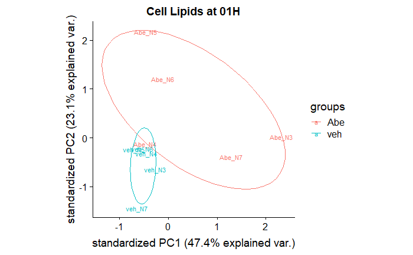

```r
#source("ggbiplot.R")

get_DE_lipids <- function(counts, design_mat, gr, contrasts, p.value = 0.1) {
  dls <-
    counts %>%
    perform_analysis_raw(design_mat, gr) %>%
    calculate_significance(contrasts) %>%
    decideTestsDGE(p.value = p.value)

  rownames(dls)[dls %>% as.logical()]
}

make_pca_plot <- function(tp, design_mat, gr, contrasts,
                          title = "PCA plot",
                          ellipse = T, var.axes = F) {

  tp_edger <-
    tp %>%
    get_DE_lipids(design_mat, gr, contrasts)

  if(length(tp_edger) == 0) {
    cat("No significant lipids for ", title)
    return()
  }

  if(length(tp_edger) == 1) {
    cat("Single significant lipids for ", title, " is ", tp_edger[1])
    return()
  }

  tp %>%
    na.omit %>%
    mutate(lipid = make.unique(lipid)) %>%
    filter(lipid %in% tp_edger) %>%
    select(-Transition, -type, -Blank) %>%
    column_to_rownames("lipid") %>%
    as.matrix() %>%
    t %>%
    prcomp(center = T, scale = T) ->
    derp

  tp %>%
    select(-Transition, -type, -Blank, -lipid) %>%
    colnames() ->
    derp1

  derp %>%
    ggbiplot(ellipse = ellipse,
             labels = derp1,
             groups = substr(derp1, 1, 3),
             var.axes = var.axes
             ) +
    ggtitle(title) +
    cowplot::theme_cowplot()
}

#svglite::svglite("figures/primary_pca_cl_01h.svg")
cl_01h %>%
  make_pca_plot(design_01h, gr_01h, contrasts_01h, "Cell Lipids at 01H")
```

```r
#dev.off()

#svglite::svglite("figures/primary_pca_ml_01h.svg")
ml_01h %>%
  make_pca_plot(design_01h, gr_01h, contrasts_01h, "Media Lipids at 01H")
```

```
No significant lipids for  Media Lipids at 01HNULL
```

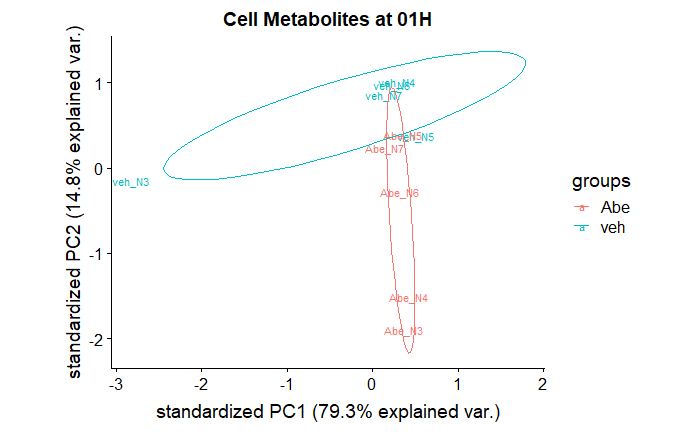

```r
#dev.off()

#svglite::svglite("figures/primary_pca_cm_01h.svg")
cm_01h %>%
  make_pca_plot(design_01h, gr_01h, contrasts_01h, "Cell Metabolites at 01H")
```

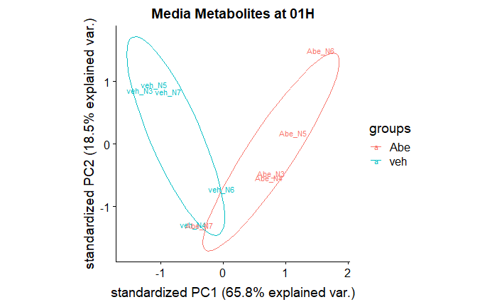

```r
#dev.off()

#svglite::svglite("figures/primary_pca_mm_01h.svg")
mm_01h %>%
  make_pca_plot(design_01h, gr_01h, contrasts_01h, "Media Metabolites at 01H")
```

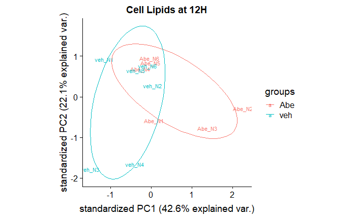

```r
#dev.off()

#svglite::svglite("figures/primary_pca_cl_12h.svg")
cl_12h %>%
  make_pca_plot(design_12h, gr_12h, contrasts_12h, "Cell Lipids at 12H")
```

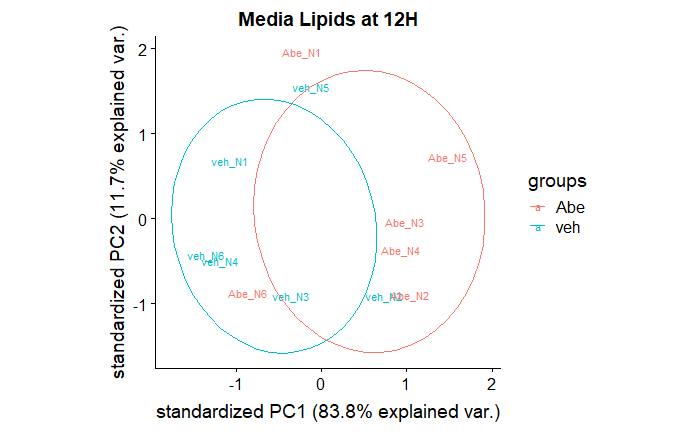

```r
#dev.off()

#svglite::svglite("figures/primary_pca_ml_12h.svg")
ml_12h %>%
  make_pca_plot(design_12h, gr_12h, contrasts_12h, "Media Lipids at 12H")
```

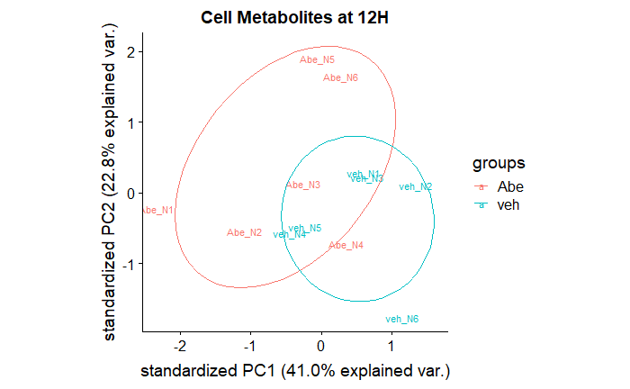

```r
#dev.off()

#svglite::svglite("figures/primary_pca_cm_12h.svg")
cm_12h %>%
  make_pca_plot(design_12h, gr_12h, contrasts_12h, "Cell Metabolites at 12H")
```

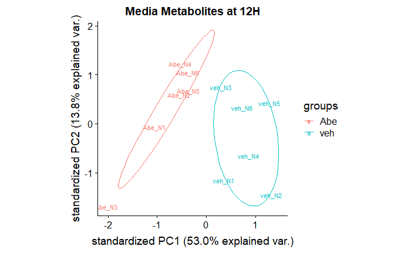

```r
#dev.off()

#svglite::svglite("figures/primary_pca_mm_12h.svg")
mm_12h %>%
  make_pca_plot(design_12h, gr_12h, contrasts_12h, "Media Metabolites at 12H")
```

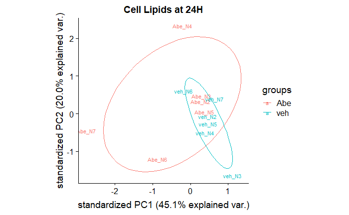

```r
#dev.off()

#svglite::svglite("figures/primary_pca_cl_24h.svg")
cl_24h %>%
  make_pca_plot(design_12h, gr_12h, contrasts_12h, "Cell Lipids at 24H")
```

```r
#dev.off()

#svglite::svglite("figures/primary_pca_ml_24h.svg")
ml_24h %>%
  make_pca_plot(design_12h, gr_12h, contrasts_12h, "Media Lipids at 24H")
```

```
Single significant lipids for  Media Lipids at 24H  is  2-Hydroxymyristoylcarnitine, 3-hydroxytetradecanoylcarnitineNULL
```

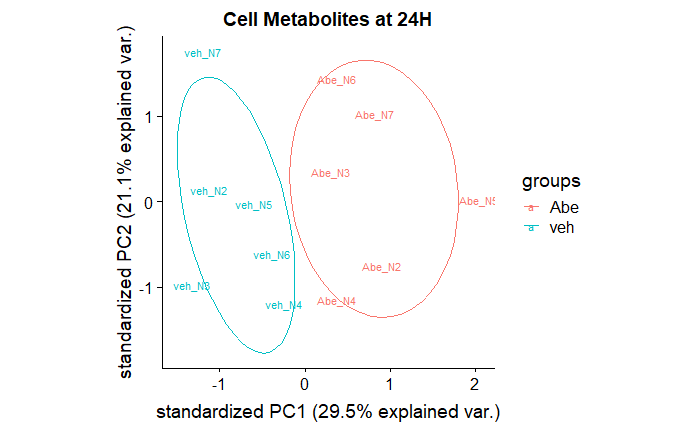

```r
#dev.off()

#svglite::svglite("figures/primary_pca_cm_24h.svg")
cm_24h %>%
  make_pca_plot(design_12h, gr_12h, contrasts_12h, "Cell Metabolites at 24H")
```

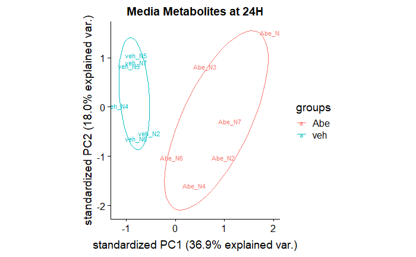

```r
#dev.off()

#svglite::svglite("figures/primary_pca_mm_24h.svg")
mm_24h %>%
  make_pca_plot(design_12h, gr_12h, contrasts_12h, "Media Metabolites at 24H")
```

```r
#dev.off()
```

#### Heatmaps

```r
make_heatmap <- function(tp, design_mat, gr, contrasts, title = "Heat-map") {

  DElist <-
    tp %>%
    get_DE_lipids(design_mat, gr, contrasts)

  if(length(DElist) == 0) {
    cat("No significant lipids for ", title)
    return()
  }

  if(length(DElist) == 1) {
    cat("Single significant lipids for ", title, " is ", DElist[1])
    return()
  }

  tp %>%
    mutate(lipid = make.unique(lipid)) %>%
    filter(lipid %in% DElist) %>%
    select(-Transition, -type) %>%
    mutate_if(is.numeric, log2) %>%
    mutate_if(is.numeric, list(~ . - Blank)) %>%
    select(-Blank) %>%
    column_to_rownames("lipid") %>%
    as.matrix() %>%
    pheatmap::pheatmap(clustering_distance_cols = "maximum",
                       main = title)
}
svglite::svglite("figures/primary_heatmap_cl_01h.svg")
cl_01h %>%
  make_heatmap(design_01h, gr_01h, contrasts_01h, "Cell Lipids at 01H")
dev.off()
```

```r
svglite::svglite("figures/primary_heatmap_ml_01h.svg")
```

```r
ml_01h %>%
  make_heatmap(design_01h, gr_01h, contrasts_01h, "Media Lipids at 01H")
```

```
No significant lipids for  Media Lipids at 01HNULL
```

```r
dev.off()
```

```r
svglite::svglite("figures/primary_heatmap_cm_01h.svg")
cm_01h %>%
  make_heatmap(design_01h, gr_01h, contrasts_01h, "Cell Metabolites at 01H")
dev.off()
```

```r
svglite::svglite("figures/primary_heatmap_mm_01h.svg")
```

```r
mm_01h %>%
  make_heatmap(design_01h, gr_01h, contrasts_01h, "Media Metabolites at 01H")
dev.off()
```

```r
svglite::svglite("figures/primary_heatmap_cl_12h.svg")
```

```r
cl_12h %>%
  make_heatmap(design_12h, gr_12h, contrasts_12h, "Cell Lipids at 12H")
dev.off()
```

```r
svglite::svglite("figures/primary_heatmap_ml_12h.svg")
```

```r
ml_12h %>%
  make_heatmap(design_12h, gr_12h, contrasts_12h, "Media Lipids at 12H")
dev.off()
```

```r
svglite::svglite("figures/primary_heatmap_cm_12h.svg")
```

```r
cm_12h %>%
  make_heatmap(design_12h, gr_12h, contrasts_12h, "Cell Metabolites at 12H")
dev.off()
```

```r
svglite::svglite("figures/primary_heatmap_mm_12h.svg")
```

```r
mm_12h %>%
  make_heatmap(design_12h, gr_12h, contrasts_12h, "Media Metabolites at 12H")
dev.off()
```

```r
svglite::svglite("figures/primary_heatmap_cl_24h.svg")
```

```r
cl_24h %>%
  make_heatmap(design_12h, gr_12h, contrasts_12h, "Cell Lipids at 24H")
dev.off()
```

```r
svglite::svglite("figures/primary_heatmap_ml_24h.svg")
```

```r
ml_24h %>%
  make_heatmap(design_12h, gr_12h, contrasts_12h, "Media Lipids at 24H")
```

```
Single significant lipids for  Media Lipids at 24H  is  2-Hydroxymyristoylcarnitine, 3-hydroxytetradecanoylcarnitineNULL
```

```r
dev.off()
```

```r
svglite::svglite("figures/primary_heatmap_cm_24h.svg")
cm_24h %>%
  make_heatmap(design_12h, gr_12h, contrasts_12h, "Cell Metabolites at 24H")
dev.off()
```

```r
svglite::svglite("figures/primary_heatmap_mm_24h.svg")
```

```r
mm_24h %>%
  make_heatmap(design_12h, gr_12h, contrasts_12h, "Media Metabolites at 24H")
dev.off()
```